# 22015765_SaniyaBist

Data Preparation

Importing all the required libraries required in sales data

Write a python program to merge data from each month into one CSV and read in updated dataframe.

```python
import os
import numpy as np
import pandas as pd
import matplotlib.pyplot as plt
%matplotlib inline
```

(concat) Concatenation refers to joining. This function is used to join two or more arrays of the same shape along a specified axis. We can use a dataframe of pandas to read CSV data into an array in python. We can do this by using the value() function. For this, we will have to read the dataframe and then convert it into a numpy array by using the value() function from the pandas’ library.

```python
df = pd.concat(map(pd.read_csv,['Sales_April_2019.csv', 'Sales_August_2019.csv', 'Sales_December_2019.csv',
                                'Sales_February_2019.csv', 'Sales_January_2019.csv', 'Sales_July_2019.csv',
                                'Sales_June_2019.csv','Sales_March_2019.csv','Sales_May_2019.csv',
                                'Sales_November_2019.csv', 'Sales_October_2019.csv', 'Sales_September_2019.csv']))
```

Df is use to define the function. It shows the total dataframe.

```python
df
```

|  | Order ID | Product | Quantity Ordered | Price Each | Order Date | Purchase Address |
| --- | --- | --- | --- | --- | --- | --- |
| 0 | 176558.0 | USB-C Charging Cable | 2.0 | 11.95 | 4/19/2019 8:46 | 917 1st St, Dallas, TX 75001 |
| 1 | NaN | NaN | NaN | NaN | NaN | NaN |
| 2 | 176559.0 | Bose SoundSport Headphones | 1.0 | 99.99 | 4/7/2019 22:30 | 682 Chestnut St, Boston, MA 02215 |
| 3 | 176560.0 | Google Phone | 1.0 | 600.00 | 4/12/2019 14:38 | 669 Spruce St, Los Angeles, CA 90001 |
| 4 | 176560.0 | Wired Headphones | 1.0 | 11.99 | 4/12/2019 14:38 | 669 Spruce St, Los Angeles, CA 90001 |
| ... | ... | ... | ... | ... | ... | ... |
| 11681 | 259353.0 | AAA Batteries (4-pack) | 3.0 | 2.99 | 9/17/2019 20:56 | 840 Highland St, Los Angeles, CA 90001 |
| 11682 | 259354.0 | iPhone | 1.0 | 700.00 | 9/1/2019 16:00 | 216 Dogwood St, San Francisco, CA 94016 |
| 11683 | 259355.0 | iPhone | 1.0 | 700.00 | 9/23/2019 7:39 | 220 12th St, San Francisco, CA 94016 |
| 11684 | 259356.0 | 34in Ultrawide Monitor | 1.0 | 379.99 | 9/19/2019 17:30 | 511 Forest St, San Francisco, CA 94016 |
| 11685 | 259357.0 | USB-C Charging Cable | 1.0 | 11.95 | 9/30/2019 0:18 | 250 Meadow St, San Francisco, CA 94016 |

186850 rows × 6 columns

The head() function is used to get the first n rows. This function returns the first n rows for the object based on position.

```python
df.head()
```

|  | Order ID | Product | Quantity Ordered | Price Each | Order Date | Purchase Address |
| --- | --- | --- | --- | --- | --- | --- |
| 0 | 176558.0 | USB-C Charging Cable | 2.0 | 11.95 | 4/19/2019 8:46 | 917 1st St, Dallas, TX 75001 |
| 1 | NaN | NaN | NaN | NaN | NaN | NaN |
| 2 | 176559.0 | Bose SoundSport Headphones | 1.0 | 99.99 | 4/7/2019 22:30 | 682 Chestnut St, Boston, MA 02215 |
| 3 | 176560.0 | Google Phone | 1.0 | 600.00 | 4/12/2019 14:38 | 669 Spruce St, Los Angeles, CA 90001 |
| 4 | 176560.0 | Wired Headphones | 1.0 | 11.99 | 4/12/2019 14:38 | 669 Spruce St, Los Angeles, CA 90001 |

The tail() function is used to get the last n rows. This function returns the last n rows for the object based on position.

```python
df.tail()
```

|  | Order ID | Product | Quantity Ordered | Price Each | Order Date | Purchase Address |
| --- | --- | --- | --- | --- | --- | --- |
| 11681 | 259353.0 | AAA Batteries (4-pack) | 3.0 | 2.99 | 9/17/2019 20:56 | 840 Highland St, Los Angeles, CA 90001 |
| 11682 | 259354.0 | iPhone | 1.0 | 700.00 | 9/1/2019 16:00 | 216 Dogwood St, San Francisco, CA 94016 |
| 11683 | 259355.0 | iPhone | 1.0 | 700.00 | 9/23/2019 7:39 | 220 12th St, San Francisco, CA 94016 |
| 11684 | 259356.0 | 34in Ultrawide Monitor | 1.0 | 379.99 | 9/19/2019 17:30 | 511 Forest St, San Francisco, CA 94016 |
| 11685 | 259357.0 | USB-C Charging Cable | 1.0 | 11.95 | 9/30/2019 0:18 | 250 Meadow St, San Francisco, CA 94016 |

info() function will tell you how many entrees you have, the names of each column, the data type of each column, and how many non-null values you have in each column. You can compare the quantity of non-null values to the total number of entries to find which columns have null values.

```python
df.info()
```

```
<class 'pandas.core.frame.DataFrame'>
Int64Index: 186850 entries, 0 to 11685
Data columns (total 6 columns):
 #   Column            Non-Null Count   Dtype
---  ------            --------------   -----
 0   Order ID          185950 non-null  float64
 1   Product           185950 non-null  object
 2   Quantity Ordered  185950 non-null  float64
 3   Price Each        185950 non-null  float64
 4   Order Date        185950 non-null  object
 5   Purchase Address  185950 non-null  object
dtypes: float64(3), object(3)
memory usage: 10.0+ MB
```

The describe() function is used to generate descriptive statistics that summarize the dataset’s distribution, excluding NaN values.

```python
df.describe()
```

|  | Order ID | Quantity Ordered | Price Each |
| --- | --- | --- | --- |
| count | 185950.000000 | 185950.000000 | 185950.000000 |
| mean | 230417.569379 | 1.124383 | 184.399735 |
| std | 51512.737110 | 0.442793 | 332.731330 |
| min | 141234.000000 | 1.000000 | 2.990000 |
| 25% | 185831.250000 | 1.000000 | 11.950000 |
| 50% | 230367.500000 | 1.000000 | 14.950000 |
| 75% | 275035.750000 | 1.000000 | 150.000000 |
| max | 319670.000000 | 9.000000 | 1700.000000 |

Maximum function is use to find the maximum values across the data frame.

```python
df.max()
```

```
C:\Users\Saniya Bist\AppData\Local\Temp\ipykernel_840\1151452817.py:1: FutureWarning: Dropping of nuisance columns in DataFrame reductions (with 'numeric_only=None') is deprecated; in a future version this will raise TypeError.  Select only valid columns before calling the reduction.
  df.max()
```

```
Order ID            319670.0
Quantity Ordered         9.0
Price Each            1700.0
dtype: float64
```

Minimum function is use to find the minimum values across the data frame.

```python
df.min()
```

```
C:\Users\Saniya Bist\AppData\Local\Temp\ipykernel_840\3962516015.py:1: FutureWarning: Dropping of nuisance columns in DataFrame reductions (with 'numeric_only=None') is deprecated; in a future version this will raise TypeError.  Select only valid columns before calling the reduction.
  df.min()
```

```
Order ID            141234.00
Quantity Ordered         1.00
Price Each               2.99
dtype: float64
```

Mean function is use to find the average values of the dataframe.

```python
df.mean()
```

```
C:\Users\Saniya Bist\AppData\Local\Temp\ipykernel_840\3698961737.py:1: FutureWarning: Dropping of nuisance columns in DataFrame reductions (with 'numeric_only=None') is deprecated; in a future version this will raise TypeError.  Select only valid columns before calling the reduction.
  df.mean()
```

```
Order ID            230417.569379
Quantity Ordered         1.124383
Price Each             184.399735
dtype: float64
```

1. Remove the NaN missing values from updated data frame.

```python
df.isnull().sum()
```

```
Order ID            900
Product             900
Quantity Ordered    900
Price Each          900
Order Date          900
Purchase Address    900
dtype: int64
```

```python
df[df.isnull().any(axis=1)]
```

|  | Order ID | Product | Quantity Ordered | Price Each | Order Date | Purchase Address |
| --- | --- | --- | --- | --- | --- | --- |
| 1 | NaN | NaN | NaN | NaN | NaN | NaN |
| 356 | NaN | NaN | NaN | NaN | NaN | NaN |
| 519 | NaN | NaN | NaN | NaN | NaN | NaN |
| 735 | NaN | NaN | NaN | NaN | NaN | NaN |
| 1149 | NaN | NaN | NaN | NaN | NaN | NaN |
| ... | ... | ... | ... | ... | ... | ... |
| 11384 | NaN | NaN | NaN | NaN | NaN | NaN |
| 11399 | NaN | NaN | NaN | NaN | NaN | NaN |
| 11468 | NaN | NaN | NaN | NaN | NaN | NaN |
| 11574 | NaN | NaN | NaN | NaN | NaN | NaN |
| 11662 | NaN | NaN | NaN | NaN | NaN | NaN |

900 rows × 6 columns

```python
df.dropna(inplace=True)
df.isnull().sum()
```

```
Order ID            0
Product             0
Quantity Ordered    0
Price Each          0
Order Date          0
Purchase Address    0
dtype: int64
```

1. Convert Quantity Ordered and Price Each to numeric.

```python
df.dtypes
```

```
Order ID            float64
Product              object
Quantity Ordered    float64
Price Each          float64
Order Date           object
Purchase Address     object
dtype: object
```

```python
df['Quantity Ordered'] = pd.to_numeric(df['Quantity Ordered'])
df['Price Each'] = pd.to_numeric(df['Price Each'])
```

```python
df['Quantity Ordered'].dtypes
```

```
dtype('float64')
```

```python
df['Price Each'].dtypes
```

```
dtype('float64')
```

1. Create a new column named Month from Ordered Date of updated dataframe and convert it to integer as data type.

```python
df["Month"] = df["Order Date"].apply(lambda x : x.split('/')[0])
```

```python
df["Month"]=df["Month"].astype('Int32')
df["Month"].unique()
```

```
<IntegerArray>
[4, 5, 8, 9, 12, 1, 2, 3, 7, 6, 11, 10]
Length: 12, dtype: Int32
```

1. Create a new column named City from Purchase Address based on the value in updated dataframe

```python
df["City"] = df["Purchase Address"].apply(lambda x: x.split(',')[1])
df['City'].unique()
```

```
array([' Dallas', ' Boston', ' Los Angeles', ' San Francisco', ' Seattle',
       ' Atlanta', ' New York City', ' Portland', ' Austin'], dtype=object)
```

1. Data Analysis

3.1. Show summary statistics of sum, mean, standard deviation, skewness, and kurtosis of any chosen variable.

```python
sum_stat = df["Price Each"].sum()
mean_stat =df["Price Each"].mean()
standdev_stat =df["Price Each"].std()
skew_stat =df["Price Each"].skew()
kurt_stat =df["Price Each"].kurt()
print('The total sum of Price of each product is:', sum_stat)
print('The total mean of Price of each product is:', mean_stat)
print('The total standard deviation of Price of each product is:', standdev_stat)
print('The total skewness of Price of each product is:', skew_stat)
print('The total kurtosis of Price of each product is:', kurt_stat)
```

```
The total sum of Price of each product is: 34289130.67999999
The total mean of Price of each product is: 184.3997347670135
The total standard deviation of Price of each product is: 332.7313298840936
The total skewness of Price of each product is: 2.8721487292935257
The total kurtosis of Price of each product is: 9.094568341148197
```

3.2. Calculate and show correlation of all variables.

```python
correlation = df.corr()
correlation
```

|  | Order ID | Quantity Ordered | Price Each | Month |
| --- | --- | --- | --- | --- |
| Order ID | 1.000000 | 0.000702 | -0.002857 | 0.993063 |
| Quantity Ordered | 0.000702 | 1.000000 | -0.148272 | 0.000791 |
| Price Each | -0.002857 | -0.148272 | 1.000000 | -0.003375 |
| Month | 0.993063 | 0.000791 | -0.003375 | 1.000000 |

1. Data Exploration
1. Which Month has the best sales? and how much was the earning in that month? Make a bar graph of sales as well.

```python
df['Sales'] = df['Quantity Ordered'] * df['Price Each']
Monthly_Sales = df.groupby('Month').sum()["Sales"]
Monthly_Sales
```

```
Month
1     1822256.73
2     2202022.42
3     2807100.38
4     3390670.24
5     3152606.75
6     2577802.26
7     2647775.76
8     2244467.88
9     2097560.13
10    3736726.88
11    3199603.20
12    4613443.34
Name: Sales, dtype: float64
```

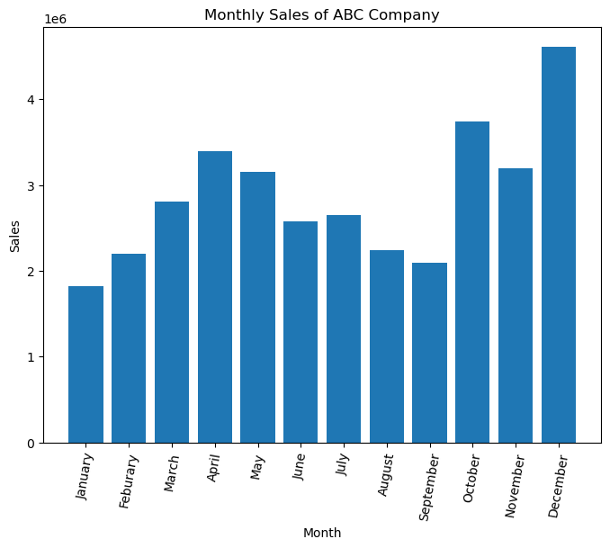

```python
Monthly_Sales.index = ['January', 'Feburary', 'March', 'April', 'May', 'June',
                       'July', 'August', 'September', 'October', 'November', 'December']

plt.figure(figsize=(8, 6))

plt.bar(Monthly_Sales.index, Monthly_Sales.values)
plt.xlabel("Month")
plt.xticks(Monthly_Sales.index, rotation=80)
plt.ylabel("Sales")
plt.title("Monthly Sales of ABC Company")

plt.show()
```

1. Which city has sold the highest product?

```python
City_Sales = df.groupby('City').sum()["Quantity Ordered"]
City_Sales
```

```
City
 Atlanta          16602.0
 Austin           11153.0
 Boston           22528.0
 Dallas           16730.0
 Los Angeles      33289.0
 New York City    27932.0
 Portland         14053.0
 San Francisco    50239.0
 Seattle          16553.0
Name: Quantity Ordered, dtype: float64
```

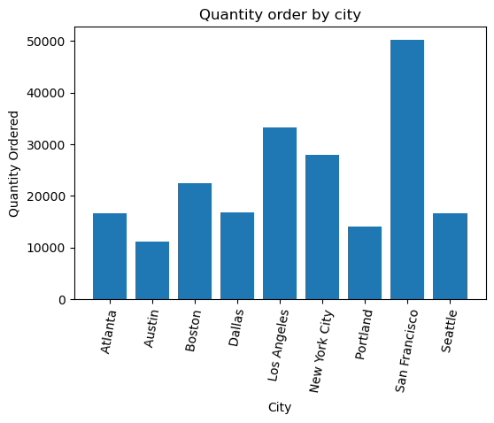

```python
plt.figure(figsize=(6, 4))

plt.bar(City_Sales.index, City_Sales.values)
plt.xlabel("City")
plt.xticks(City_Sales.index, rotation=80)
plt.ylabel("Quantity Ordered")
plt.title("Quantity order by city")
plt.show()
```

1. Which product was sold the most in overall? Illustrate it through bar graph

```python
Product_Sales = df.groupby('Product').sum()["Quantity Ordered"]
Product_Sales
```

```
Product
20in Monitor                   4129.0
27in 4K Gaming Monitor         6244.0
27in FHD Monitor               7550.0
34in Ultrawide Monitor         6199.0
AA Batteries (4-pack)         27635.0
AAA Batteries (4-pack)        31017.0
Apple Airpods Headphones      15661.0
Bose SoundSport Headphones    13457.0
Flatscreen TV                  4819.0
Google Phone                   5532.0
LG Dryer                        646.0
LG Washing Machine              666.0
Lightning Charging Cable      23217.0
Macbook Pro Laptop             4728.0
ThinkPad Laptop                4130.0
USB-C Charging Cable          23975.0
Vareebadd Phone                2068.0
Wired Headphones              20557.0
iPhone                         6849.0
Name: Quantity Ordered, dtype: float64
```

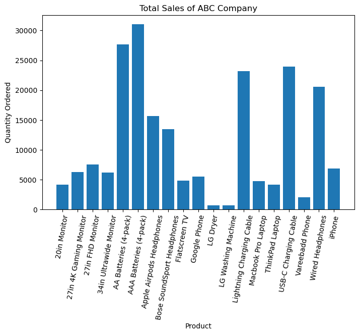

```python
plt.figure(figsize=(8, 5))

plt.bar(Product_Sales.index, Product_Sales.values)
plt.xlabel("Product")
plt.xticks(Product_Sales.index, rotation=80)
plt.ylabel("Quantity Ordered")
plt.title("Total Sales of ABC Company")
plt.show()
```

1. Write a Python program to show histogram plot of any chosen variables. Use proper labels in the graph.

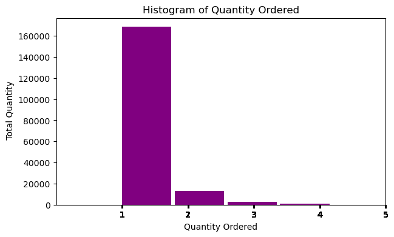

```python
plt.figure(figsize=(7, 4))
plt.hist(df['Quantity Ordered'], width= 0.75, color = 'purple')
plt.xticks(df['Quantity Ordered'])
plt.xlim(0,5)
plt.xlabel("Quantity Ordered")
plt.ylabel(" Total Quantity")
plt.title("Histogram of Quantity Ordered")
plt.yticks([0, 20000, 40000, 60000, 80000, 100000, 120000, 140000, 160000])
plt.show()
```